# Loan Data from Prosper

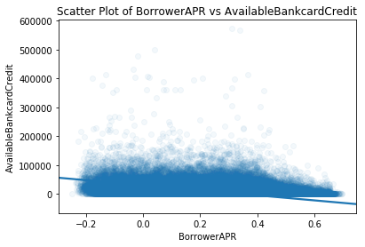

```python
# Plot the scatter plot
sns.regplot(x='BorrowerAPR', y='AvailableBankcardCredit', data=loan_data1, x_jitter=0.3, scatter_kws={'alpha':1/20})

# Add labels and title
plt.xlabel("BorrowerAPR")
plt.ylabel("AvailableBankcardCredit")
plt.title("Scatter Plot of BorrowerAPR vs AvailableBankcardCredit")

# Show the plot
plt.show()
```

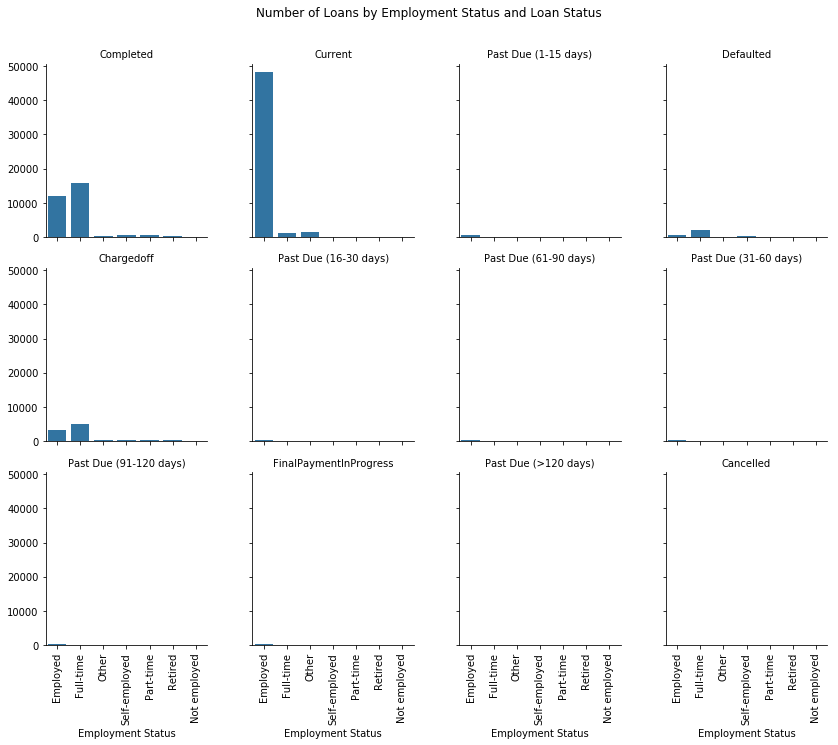

```python
# Create a facet grid of countplots with EmploymentStatus for each LoanStatus
g = sns.FacetGrid(data=loan_data1, col='LoanStatus', col_wrap=4)
g.map(sns.countplot, 'EmploymentStatus', order=loan_data1['EmploymentStatus'].value_counts().index)

# Set the titles and x-axis labels for each subplot
g.set_titles(row_template='{row_name}', col_template='{col_name}')
g.set_xlabels('Employment Status')

# Rotate the x-axis tick labels for readability
g.set_xticklabels(rotation=90)

# Add a title to the plot
plt.suptitle('Number of Loans by Employment Status and Loan Status', y=1.05)

# Show the plot
plt.show()
```

The majority of employment status is Employed, so we will focus the next analysis of employed borrowers

```python
current_employed = loan_data1[loan_data1['EmploymentStatus']=='Employed']
```

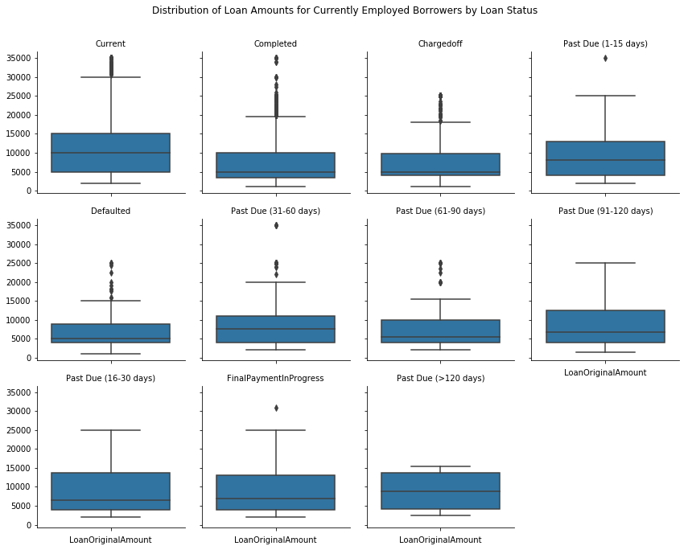

```python
g = sns.FacetGrid(data = current_employed, col = 'LoanStatus',col_wrap=4, col_order = current_employed['LoanStatus'].value_counts().index)
g.map(sns.boxplot, "LoanOriginalAmount", orient="v");
g.set_titles(row_template = '{row_name}', col_template = '{col_name}')
g.set_xticklabels(rotation=90)
plt.suptitle('Distribution of Loan Amounts for Currently Employed Borrowers by Loan Status',y=1.05)
plt.show()
```

The median for the current loan status is higher than that of others. From previous distribution we know that only minority are out side the current and completed loan status values, so we could ignore other loan status.

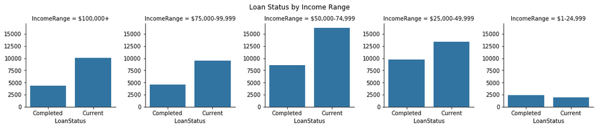

```python
plt.figure(figsize=(8,8))
g = sns.FacetGrid(data = loan_data1, col = 'IncomeRange', col_order=income_order[:-2]);
g.map(sns.countplot, 'LoanStatus', order = ['Completed','Current']);

plt.suptitle('Loan Status by Income Range',y=1.05);
plt.show();
```

For all the income range those who have current loan status are almost as twice or 1.5 the number of those who have completed loan status. The only exception is that less than 25k income range where both are really close and the completed is slightly higher in value.

```python
xscale = 'log'
```

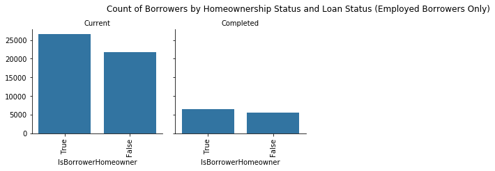

```python
g = sns.FacetGrid(data = current_employed, col = 'LoanStatus',col_wrap=4,col_order=current_employed.LoanStatus.value_counts().index[:2])
g.map(sns.countplot, "IsBorrowerHomeowner", order= current_employed['IsBorrowerHomeowner'].value_counts().index,orient="v");
g.set_titles(row_template = '{row_name}', col_template = '{col_name}')
g.set_xticklabels(rotation=90)
plt.suptitle("Count of Borrowers by Homeownership Status and Loan Status (Employed Borrowers Only)",y=1.05)
plt.show()
```

In both the current and completed loan status, more borrowers are home owners.